# Analyses

- Show All Code
- Hide All Code
- View Source

Author

Lars Schilling

Published

2026-09-17 16:50:46

# Dependencies

```r
# Path
path <- "../data/llm_reviews/parsed"

# File name
llm_reviews <- "results.parquet"

# Package mangagement
if (!requireNamespace("pacman", quietly = TRUE)) install.packages("pacman")

pacman::p_load(
  arrow,
  tidyverse,
  lme4,
  car,
  emmeans,
  multcomp,
  multcompView,
  broom.mixed,
  knitr,
  kableExtra,
  cowplot,
  ggtext,
  rlang,
  styler,
  grid,
  flextable,
  officer
)
```

# Hardcoded values

```r
# Column names
CONFIG_COL <- c("model", "hyperparameter", "chain_of_thought", "note_taking", "config_group")
COMBO_COL <- c("paper_id", CONFIG_COL)
SCORE_COL <- c("actionability_label", "grounding_specificity_label", "verifiability_label", "helpfulness_label")

# Bootstrap settings
NUM_ITERATIONS <- 2000
CONFIDENCE_LVL <- 0.95
```

# Data loading

```r
full_path_llm_reviews <- file.path(path, llm_reviews)


review_data <- read_parquet(full_path_llm_reviews,
  as_data_frame = TRUE, mmap = TRUE
)
```

# Data processing

## Transformation and calculation

```r
review_data_calculated <- review_data |>
  # Factorize ID columns
  mutate(
    paper_id = as.factor(paper_id),
    config_group = as.factor(config_group)
  ) |>
  # Reformat configuration columns
  mutate(
    model = recode_values(
      model,
      "gpt-5-mini-2025-08-07" ~ "GPT-5 Mini",
      "gpt-5-nano-2025-08-07" ~ "GPT-5 Nano",
      "gpt-4o-2024-11-20" ~ "GPT-4o",
      "gpt-4o-mini-2024-07-18" ~ "GPT-4o Mini",
      "o4-mini-2025-04-16" ~ "o4 Mini",
      "o3-mini-2025-01-31" ~ "o3 Mini",
      "gpt-3.5-turbo-0125" ~ "GPT-3.5 Turbo",
      "llama-3.3-70b-versatile" ~ "Llama 3.3 (70B)",
      "gemini-3-flash-preview" ~ "Gemini-3 Flash"
    ),
    hyperparameter = case_when(
      !is.na(reasoning_effort) ~ paste0("Re ", reasoning_effort),
      !is.na(temperature) ~ paste0("Tempr ", temperature),
      TRUE ~ "default"
    ),
    chain_of_thought = recode_values(
      chain_of_thought,
      "Explain your thought process step by step." ~ "True",
      "" ~ "False"
    )
  ) |>
  # Convert all scores to numeric
  mutate(across(
    all_of(c(SCORE_COL)),
    ~ suppressWarnings(as.numeric(as.character(.x)))
  )) |>
  # Group to unit of analysis (reviews)
  group_by(across(all_of(COMBO_COL))) |>
  summarise(
    # Quality
    across(all_of(SCORE_COL), ~ mean(.x, na.rm = TRUE)),

    # Success
    is_success = first(generation_successful),
    .groups = "drop"
  )

# Create summary
review_data_summary <- review_data_calculated |>
  group_by(across(all_of(CONFIG_COL))) |>
  summarise(
    # Quality
    across(all_of(SCORE_COL), ~ mean(.x, na.rm = TRUE), .names = "mean_{.col}"),

    # Success
    mean_success = mean(as.logical(is_success), na.rm = TRUE),
    .groups = "drop"
  )
```

## Bootstrap

```r
# Set alpha level
global_alpha <- (1 - CONFIDENCE_LVL) / 2

# Define bootstrap function
#' Bootstrap Confidence Interval Generation
#'
#' Performs non-parametric bootstrapping to estimate uncertainty for given metrics
#'
#' @param df A data frame containing the review-level data.
#' @param group_col A character string specifying the column to group by
#' @param iterations Integer. The number of bootstrap resamples to perform.
#'   Defaults to the global \code{NUM_ITERATIONS}.
#'
#' @return A data frame containing the lower and upper confidence bounds.
#'   Columns are named using the pattern:
#'   \code{boot_[original_metric]_[lower/upper]}
bootstrap <- function(df, group_col, iterations = NUM_ITERATIONS) {
  set.seed(42)

  # Generate the distribution
  boot_distribution <- map_df(1:iterations, function(i) {
    df |>
      # Group by configuration
      group_by(.data[[group_col]]) |>
      # Sample with replacement
      slice_sample(prop = 1, replace = TRUE) |>
      summarise(
        # Quality
        across(all_of(SCORE_COL),
          ~ mean(.x, na.rm = TRUE),
          .names = "boot_{.col}"
        ),

        # Success
        boot_success_rate = mean(as.logical(is_success), na.rm = TRUE),
        .groups = "drop"
      )
  })

  # Calculate CIs
  ci_results <- boot_distribution |>
    # Group by configuration
    group_by(.data[[group_col]]) |>
    summarise(
      across(starts_with("boot_"),
        list(
          lower = ~ quantile(.x, global_alpha, na.rm = TRUE),
          upper = ~ quantile(.x, 1 - global_alpha, na.rm = TRUE)
        ),
        .names = "{.col}_{.fn}"
      ),
      .groups = "drop"
    )

  return(ci_results)
}
```

```r
# Apply bootstrap function
boot_results <- bootstrap(review_data_calculated, "config_group")
```

```r
# Join summary and bootstrap results
review_data_bootstraped <- review_data_summary |>
  left_join(boot_results, "config_group")
```

# Data plotting

## Specification curve function

The plot function for a specification curve was taken from (Cummins, 2026):

```r
specification_curve_plot_with_shading <- function(data,
                                                  outcome = "outcome",
                                                  outcome_name = "Outcome",
                                                  is_processed = NULL,
                                                  plot_title = NULL,
                                                  interval_lower = NULL,
                                                  interval_upper = NULL,
                                                  rank_by = "rank",
                                                  rank_by_outcome = FALSE,
                                                  relative_height_of_upper_plot = 0.70,
                                                  outcome_cutoff = NULL,
                                                  facet_by = NULL,
                                                  facet_ncol = 2,
                                                  shade_lower = NULL,
                                                  shade_upper = NULL,
                                                  shade_fill_by = NULL,
                                                  shade_values = NULL,
                                                  shade_alpha = 0.5,
                                                  shade_fill_constant = "red",
                                                  mutate_plots = NULL) {
  require(dplyr)
  require(tidyr)
  require(ggplot2)
  require(cowplot)
  require(ggtext)
  require(rlang)
  require(grid)

  data <- data |>
    rename(outcome = {{ outcome }}, rank = {{ rank_by }})

  # REFINEMENT
  if (rlang::quo_is_null(rlang::enquo(is_processed)) || rlang::quo_is_missing(rlang::enquo(is_processed))) {
    data <- data |> mutate(is_processed = 1.0)
  } else {
    data <- data |> mutate(is_processed = {{ is_processed }})
  }

  if (!is.null(interval_lower)) {
    data <- data |> rename(interval_lower = {{ interval_lower }})
  } else {
    data$interval_lower <- data$outcome
  }
  if (!is.null(interval_upper)) {
    data <- data |> rename(interval_upper = {{ interval_upper }})
  } else {
    data$interval_upper <- data$outcome
  }

  if (rank_by_outcome) {
    data <- data |>
      arrange(outcome) |>
      mutate(rank = dplyr::row_number())
  }

  keep_num <- c("rank", "outcome", "interval_lower", "interval_upper", "is_processed")
  if (!is.null(shade_lower)) {
    keep_num <- c(keep_num, as_name(ensym(shade_lower)))
  }
  if (!is.null(shade_upper)) {
    keep_num <- c(keep_num, as_name(ensym(shade_upper)))
  }

  data <- data |> mutate(across(.cols = -all_of(keep_num), .fns = as.factor))
  exclude_cols_base <- keep_num

  facet_name <- NULL
  if (!is.null(facet_by)) {
    facet_sym <- ensym(facet_by)
    facet_name <- as_name(facet_sym)
    if (!facet_name %in% names(data)) {
      stop("facet_by column not found in data.")
    }
  }

  # specify column that controls fill (will be facet)
  if (!is.null(shade_fill_by)) {
    fill_name <- as_name(ensym(shade_fill_by))
  } else {
    fill_name <- facet_name
  }
  if (!is.null(fill_name)) {
    exclude_cols_base <- c(exclude_cols_base, fill_name)
  }

  # resolve global fill levels & colors (so colors are consistent across facets)
  fill_levels <- if (!is.null(fill_name)) {
    levels(droplevels(as.factor(data[[fill_name]])))
  } else {
    NULL
  }
  resolved_fill <- NULL
  if (!is.null(fill_levels) && !is.null(shade_values)) {
    if (!is.null(names(shade_values)) &&
      any(nzchar(names(shade_values)))) {
      resolved_fill <- shade_values[fill_levels]
    } else {
      resolved_fill <- rep(shade_values, length.out = length(fill_levels))
      names(resolved_fill) <- fill_levels
    }
  }

  build_one <- function(df,
                        title_text = plot_title,
                        show_y_titles = TRUE) {
    # REFINEMENT: Ensure rank order for smooth ribbon rendering
    df <- df |> arrange(rank)

    p_estimates <- df |>
      mutate(outcome_name = outcome_name) |>
      ggplot(aes(rank, outcome))

    # shaded band behind points/intervals
    if (!is.null(shade_lower) && !is.null(shade_upper)) {
      lower_sym <- ensym(shade_lower)
      upper_sym <- ensym(shade_upper)

      band <- df |>
        summarise(
          ymin = dplyr::first(!!lower_sym),
          ymax = dplyr::first(!!upper_sym),
          .groups = "drop"
        )

      if (!is.null(fill_name) && fill_name %in% names(df)) {
        band$.__fill <- dplyr::first(df[[fill_name]])
        p_estimates <- p_estimates +
          geom_rect(
            data = band,
            aes(
              xmin = -Inf,
              xmax = Inf,
              ymin = ymin,
              ymax = ymax,
              fill = .__fill
            ),
            alpha = shade_alpha,
            inherit.aes = FALSE,
            show.legend = FALSE
          )
        if (!is.null(resolved_fill)) {
          p_estimates <- p_estimates + scale_fill_manual(values = resolved_fill, guide = "none")
        }
      } else {
        p_estimates <- p_estimates +
          geom_rect(
            data = band,
            aes(
              xmin = -Inf,
              xmax = Inf,
              ymin = ymin,
              ymax = ymax
            ),
            fill = shade_fill_constant,
            alpha = shade_alpha,
            inherit.aes = FALSE,
            show.legend = FALSE
          )
      }
      # ensure band is within the y-scale
      p_estimates <- p_estimates + expand_limits(y = c(band$ymin, band$ymax))
    }

    # REFINEMENT: Shaded Ribbon CI instead of linerange
    p_estimates <- p_estimates +
      geom_ribbon(aes(ymin = interval_lower, ymax = interval_upper),
        fill = "#ADD8E6", alpha = 0.4
      ) +
      geom_point(aes(alpha = is_processed), shape = "circle", size = 2) + # REFINEMENT
      scale_alpha_continuous(range = c(0.4, 1.0), guide = "none") +
      facet_grid(
        outcome_name ~ .,
        space = "free_y",
        scales = "free_y",
        switch = "y"
      ) +
      scale_y_continuous(breaks = scales::pretty_breaks()) +
      scale_x_continuous(NULL, expand = c(.02, .02)) +
      ylab(if (show_y_titles) {
        "Simulation results"
      } else {
        NULL
      }) +
      theme_minimal() +
      theme(
        legend.position = "none",
        axis.line.x = element_blank(),
        strip.placement = "outside",
        strip.background = element_rect(fill = NA, colour = NA),
        panel.spacing.x = unit(0.15, "cm"),
        strip.text.y.left = if (show_y_titles) {
          ggtext::element_markdown(
            angle = 90,
            face = "bold",
            size = 7,
            margin = margin(r = 20, l = 5) # REFINEMENT
          )
        } else {
          element_blank()
        },
        axis.text.y = element_text(
          angle = 0,
          hjust = 0.5,
          size = 6
        ),
        axis.title.y = if (show_y_titles) {
          element_text(
            size = 9,
            face = "bold",
            margin = margin(r = 4)
          )
        } else {
          element_blank()
        },
        panel.spacing = unit(0.25, "lines"),
        axis.title.x = element_blank(),
        axis.text.x = element_blank(),
        axis.ticks.x = element_blank()
      )

    if (!is.null(outcome_cutoff)) {
      p_estimates <- p_estimates + geom_hline(yintercept = outcome_cutoff, linetype = "dashed") # REFINEMENT
    }

    exclude_cols <- exclude_cols_base
    if (!is.null(facet_name)) {
      exclude_cols <- c(exclude_cols, facet_name)
    }

    p_specs <- df |>
      tidyr::pivot_longer(cols = -dplyr::all_of(exclude_cols)) |>
      arrange(rank) |>
      ggplot(aes(
        x = rank,
        y = factor(value),
        color = name
      )) +
      geom_point(size = 3.5, shape = "|") +
      facet_grid(name ~ .,
        space = "free_y",
        scales = "free_y",
        switch = "y"
      ) +
      guides(color = "none") +
      scale_x_continuous(NULL, expand = c(.02, .02)) +
      ylab(if (show_y_titles) {
        "Simulation conditions"
      } else {
        NULL
      }) +
      theme_minimal() +
      theme(
        strip.placement = "outside",
        strip.background = element_rect(fill = NA, colour = NA),
        panel.spacing.x = unit(0.15, "cm"),
        strip.text.y.left = if (show_y_titles) {
          ggtext::element_markdown(
            angle = 90,
            face = "bold",
            size = 7,
            # REFINEMENT:
            lineheight = 0.9,
            margin = margin(r = 20, l = 5)
          )
        } else {
          element_blank()
        },
        axis.text.y = element_text(
          angle = 0,
          hjust = 1,
          size = 6
        ),
        axis.title.y = if (show_y_titles) {
          element_text(
            size = 9,
            face = "bold",
            margin = margin(r = 4)
          )
        } else {
          element_blank()
        },
        panel.spacing = unit(0.25, "lines"),
        axis.title.x = element_blank(),
        axis.text.x = element_blank(),
        axis.ticks.x = element_blank()
      ) +
      scale_color_brewer(palette = "Dark2")

    if (is.function(mutate_plots)) {
      out <- mutate_plots(p_estimates, p_specs, df)
      if (inherits(out, "gg")) {
        p_estimates <- out
      } else if (is.list(out)) {
        if (length(out) >= 1) {
          p_estimates <- out[[1]]
        }
        if (length(out) >= 2) {
          p_specs <- out[[2]]
        }
      }
    }

    g_est <- ggplotGrob(p_estimates)
    g_spc <- ggplotGrob(p_specs)
    max_w <- unit.pmax(g_est$widths, g_spc$widths)
    g_est$widths <- max_w
    g_spc$widths <- max_w

    combo <- cowplot::plot_grid(
      g_est,
      g_spc,
      axis = "bltr",
      align = "v",
      ncol = 1,
      rel_heights = c(relative_height_of_upper_plot, 1)
    )
    if (!is.null(title_text)) {
      title_grob <- cowplot::ggdraw() +
        cowplot::draw_label(
          title_text,
          x = 0.5,
          hjust = 0.5,
          y = 0.5, # REFINEMENT
          vjust = 0.5, # REFINEMENT
          fontface = "bold"
        )
      combo <- cowplot::plot_grid(title_grob,
        combo,
        ncol = 1,
        rel_heights = c(0.15, 1)
      ) # REFINEMENT
    }
    combo
  }

  if (is.null(facet_by)) {
    return(build_one(data, plot_title, show_y_titles = TRUE))
  }

  facet_vals <- if (is.factor(data[[facet_name]])) {
    levels(droplevels(data[[facet_name]]))
  } else {
    unique(data[[facet_name]])
  }
  plotlist <- lapply(seq_along(facet_vals), function(i) {
    v <- facet_vals[i]
    df <- dplyr::filter(data, .data[[facet_name]] == v)
    if (nrow(df) == 0) {
      return(NULL)
    }
    local_title <- if (!is.null(plot_title)) {
      paste0(plot_title, ": ", v)
    } else {
      paste0(facet_name, ": ", v)
    }
    is_left_col <- ((i - 1) %% facet_ncol) == 0
    build_one(df, local_title, show_y_titles = is_left_col)
  })
  plotlist <- Filter(Negate(is.null), plotlist)

  cowplot::plot_grid(
    plotlist = plotlist,
    ncol = facet_ncol,
    align = "hv"
  )
}
```

## Data preparation

```r
data_plot <- review_data_bootstraped |>
  mutate(
    model = fct_relevel(
      as.factor(model),
      "Gemini-3 Flash", "Llama 3.3 (70B)", "GPT-3.5 Turbo", "o3 Mini",
      "o4 Mini", "GPT-4o Mini", "GPT-4o", "GPT-5 Nano", "GPT-5 Mini"
    ),
    hyperparameter = fct_relevel(
      as.factor(hyperparameter),
      "Tempr 1.5", "Tempr 1", "Tempr 0.5", "Tempr 0", "Re high", "Re low"
    ),
    chain_of_thought = fct_relevel(
      as.factor(chain_of_thought),
      "True", "False"
    ),
    note_taking = fct_relevel(
      as.factor(note_taking),
      "Faithful", "Turned off"
    )
  ) |>
  rename(
    `Model` = model,
    `Hyper-<br> parameter` = hyperparameter,
    `CoT<br> used` = chain_of_thought,
    `Notes` = note_taking
  )
```

## Quality metrics

### Specification curve: Helpfulness

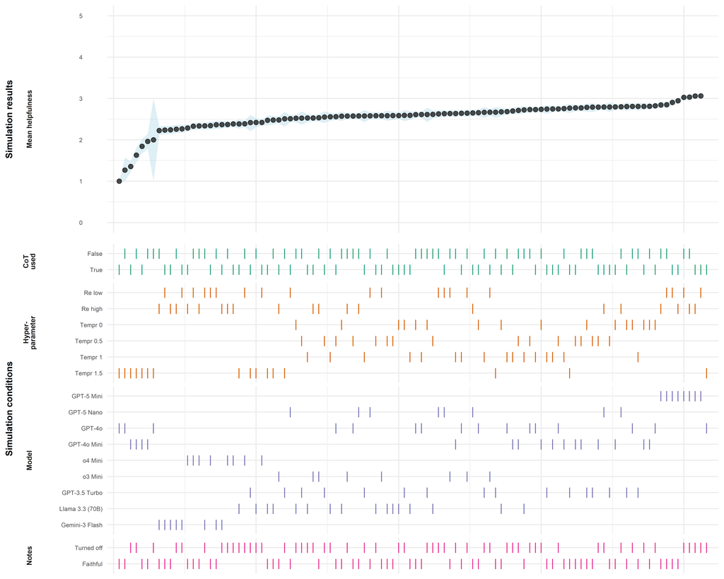

```r
data_prepared_helpfulness <- data_plot |>
  # Preprocess
  dplyr::select(
    `Model`,
    `Hyper-<br> parameter`,
    `CoT<br> used`,
    `Notes`,
    mean_success,
    mean_helpfulness_label,
    boot_helpfulness_label_lower,
    boot_helpfulness_label_upper
  ) |>
  # Summarize
  group_by(Model, `Hyper-<br> parameter`, `CoT<br> used`, Notes) |>
  summarise(
    success_rate = mean(mean_success, na.rm = TRUE),
    helpfulness = mean(mean_helpfulness_label),
    boot_helpfulness_lower = mean(boot_helpfulness_label_lower, na.rm = TRUE),
    boot_helpfulness_upper = mean(boot_helpfulness_label_upper, na.rm = TRUE),
    .groups = "drop"
  )

# Drop configurations which fail on most runs
data_prepared_filtered_helpfulness <- data_prepared_helpfulness |>
  filter(success_rate >= 0.25)

# Minimum and maximum data points
min_config_helpfulness <- min(data_prepared_helpfulness$helpfulness, na.rm = TRUE)
max_config_helpfulness <- max(data_prepared_helpfulness$helpfulness, na.rm = TRUE)

# Inference: Overlap of confidence intervals
lower_bound_max_helpfulness <- max(data_prepared_helpfulness$boot_helpfulness_lower, na.rm = TRUE)
upper_bound_min_helpfulness <- min(data_prepared_helpfulness$boot_helpfulness_lower, na.rm = TRUE)
cis_all_overlap <- lower_bound_max_helpfulness <= upper_bound_min_helpfulness

# Inference: Overlap of confidence intervals without dropped configurations
lower_bound_max_helpfulness_filt <- max(data_prepared_filtered_helpfulness$boot_helpfulness_lower, na.rm = TRUE)
upper_bound_min_helpfulness_filt <- min(data_prepared_filtered_helpfulness$boot_helpfulness_upper, na.rm = TRUE)
cis_all_overlap_filtered <- lower_bound_max_helpfulness_filt <= upper_bound_min_helpfulness_filt

# Ploting
helpfulness_spec_plot <- data_prepared_helpfulness |>
  dplyr::select(-success_rate) |>
  arrange(helpfulness) |>
  mutate(rank = row_number()) |>
  # Plot call
  specification_curve_plot_with_shading(
    outcome = helpfulness,
    outcome_name = "Mean helpfulness",
    interval_lower = "boot_helpfulness_lower",
    interval_upper = "boot_helpfulness_upper",
    rank_by = rank,
    mutate_plots = \(top, bottom, df) {
      list(top + coord_cartesian(ylim = c(0, 5)))
    }
  )

helpfulness_spec_plot
```

```r
ggsave(
  filename = "output/plots/helpfulness_spec_plot.png",
  plot = helpfulness_spec_plot,
  width = PLOT_WIDTH,
  height = PLOT_HEIGHT,
  dpi = PLOT_DPI
)
```

The estimated mean quality ranged from 1 to 3.06. While the confidence intervals did not universally overlap across the entire design space, they did not universally overlap anymore once uninterpretable configurations (a success rate below 25%) were excluded.

### Specification curve: Actionability

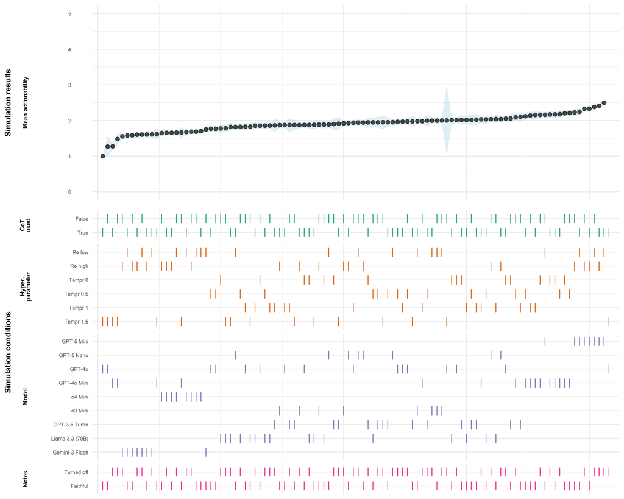

```r
data_prepared_actionability <- data_plot |>
  # Preprocess
  dplyr::select(
    `Model`,
    `Hyper-<br> parameter`,
    `CoT<br> used`,
    `Notes`,
    mean_actionability_label,
    boot_actionability_label_lower,
    boot_actionability_label_upper
  ) |>
  # Summarize
  group_by(Model, `Hyper-<br> parameter`, `CoT<br> used`, Notes) |>
  summarise(
    actionability = mean(mean_actionability_label, na.rm = TRUE),
    boot_actionability_lower = mean(boot_actionability_label_lower, na.rm = TRUE),
    boot_actionability_upper = mean(boot_actionability_label_upper, na.rm = TRUE),
    .groups = "drop"
  )

# Minimum and maximum data points
min_config_actionability <- min(data_prepared_actionability$actionability, na.rm = TRUE)
max_config_actionability <- max(data_prepared_actionability$actionability, na.rm = TRUE)

# Inference: Overlap of confidence intervals
lower_bound_max_actionability <- max(data_prepared_actionability$boot_actionability_lower, na.rm = TRUE)
upper_bound_min_actionability <- min(data_prepared_actionability$boot_actionability_upper, na.rm = TRUE)
cis_all_overlap_actionability <- lower_bound_max_actionability <= upper_bound_min_actionability

# Plotting
actionability_spec_plot <- data_prepared_actionability |>
  arrange(actionability) |>
  mutate(rank = row_number()) |>
  # Plot call
  specification_curve_plot_with_shading(
    outcome = actionability,
    outcome_name = "Mean actionability",
    interval_lower = "boot_actionability_lower",
    interval_upper = "boot_actionability_upper",
    rank_by = rank,
    mutate_plots = \(top, bottom, df) {
      list(top + coord_cartesian(ylim = c(0, 5)))
    }
  )

actionability_spec_plot
```

```r
ggsave(
  filename = "output/plots/actionability_spec_plot.png",
  plot = actionability_spec_plot,
  width = PLOT_WIDTH,
  height = PLOT_HEIGHT,
  dpi = PLOT_DPI
)
```

The estimated mean actionability of LLM-authored reviews ranged from 1 to 2.5, with confidence intervals that do not universally overlap.

### Specification curve: Grounding & Specificity

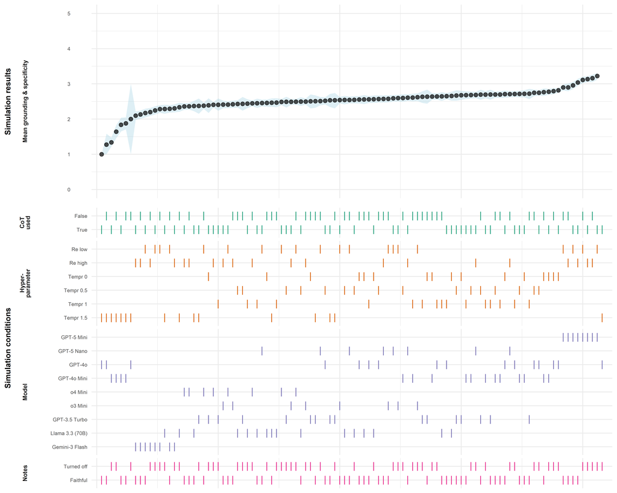

```r
data_prepared_specificity <- data_plot |>
  # Preprocess
  dplyr::select(
    `Model`,
    `Hyper-<br> parameter`,
    `CoT<br> used`,
    `Notes`,
    mean_grounding_specificity_label,
    boot_grounding_specificity_label_lower,
    boot_grounding_specificity_label_upper
  ) |>
  # Summarize
  group_by(Model, `Hyper-<br> parameter`, `CoT<br> used`, Notes) |>
  summarise(
    specificity = mean(mean_grounding_specificity_label, na.rm = TRUE),
    boot_specificity_lower = mean(boot_grounding_specificity_label_lower, na.rm = TRUE),
    boot_specificity_upper = mean(boot_grounding_specificity_label_upper, na.rm = TRUE),
    .groups = "drop"
  )

# Minimum and maximum data points
min_config_specificity <- min(data_prepared_specificity$specificity, na.rm = TRUE)
max_config_specificity <- max(data_prepared_specificity$specificity, na.rm = TRUE)

# Inference: Overlap of confidence intervals
lower_bound_max_specificity <- max(data_prepared_specificity$boot_specificity_lower, na.rm = TRUE)
upper_bound_min_specificity <- min(data_prepared_specificity$boot_specificity_upper, na.rm = TRUE)
cis_all_overlap_specificity <- lower_bound_max_specificity <= upper_bound_min_specificity

# Plotting
specificity_spec_plot <- data_prepared_specificity |>
  arrange(specificity) |>
  mutate(rank = row_number()) |>
  # Plot call
  specification_curve_plot_with_shading(
    outcome = specificity,
    outcome_name = "Mean grounding & specificity",
    interval_lower = "boot_specificity_lower",
    interval_upper = "boot_specificity_upper",
    rank_by = rank,
    mutate_plots = \(top, bottom, df) {
      list(top + coord_cartesian(ylim = c(0, 5)))
    }
  )

specificity_spec_plot
```

```r
ggsave(
  filename = "output/plots/specificity_spec_plot.png",
  plot = specificity_spec_plot,
  width = PLOT_WIDTH,
  height = PLOT_HEIGHT,
  dpi = PLOT_DPI
)
```

The estimated mean grounding and specificity of LLM-authored reviews ranged from 1 to 3.22, with confidence intervals that do not universally overlap.

### Specification curve: Verifiability

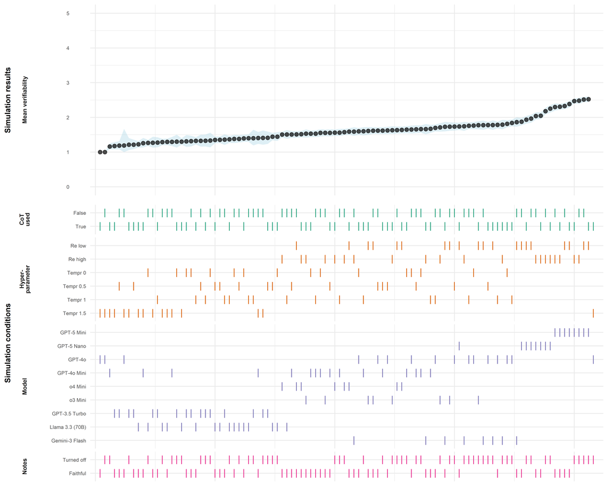

```r
data_prepared_verifiability <- data_plot |>
  # Preprocess
  dplyr::select(
    `Model`,
    `Hyper-<br> parameter`,
    `CoT<br> used`,
    `Notes`,
    mean_verifiability_label,
    boot_verifiability_label_lower,
    boot_verifiability_label_upper
  ) |>
  # Summarize
  group_by(Model, `Hyper-<br> parameter`, `CoT<br> used`, Notes) |>
  summarise(
    verifiability = mean(mean_verifiability_label, na.rm = TRUE),
    boot_verifiability_lower = mean(boot_verifiability_label_lower, na.rm = TRUE),
    boot_verifiability_upper = mean(boot_verifiability_label_upper, na.rm = TRUE),
    .groups = "drop"
  )

# Minimum and maximum data points
min_config_verifiability <- min(data_prepared_verifiability$verifiability, na.rm = TRUE)
max_config_verifiability <- max(data_prepared_verifiability$verifiability, na.rm = TRUE)

# Inference: Overlap of confidence intervals
lower_bound_max_verifiability <- max(data_prepared_verifiability$boot_verifiability_lower, na.rm = TRUE)
upper_bound_min_verifiability <- min(data_prepared_verifiability$boot_verifiability_upper, na.rm = TRUE)
cis_all_overlap_verifiability <- lower_bound_max_verifiability <= upper_bound_min_verifiability

# Plotting
verifiability_spec_plot <- data_prepared_verifiability |>
  arrange(verifiability) |>
  mutate(rank = row_number()) |>
  # Plot call
  specification_curve_plot_with_shading(
    outcome = verifiability,
    outcome_name = "Mean verifiability",
    interval_lower = "boot_verifiability_lower",
    interval_upper = "boot_verifiability_upper",
    rank_by = rank,
    mutate_plots = \(top, bottom, df) {
      list(top + coord_cartesian(ylim = c(0, 5)))
    }
  )

verifiability_spec_plot
```

```r
ggsave(
  filename = "output/plots/verifiability_spec_plot.png",
  plot = verifiability_spec_plot,
  width = PLOT_WIDTH,
  height = PLOT_HEIGHT,
  dpi = PLOT_DPI
)
```

The estimated mean verifiability of LLM-authored reviews ranged from 1 to 2.52, with confidence intervals that do not universally overlap.

## Success metric

### Specification curve: Success rate

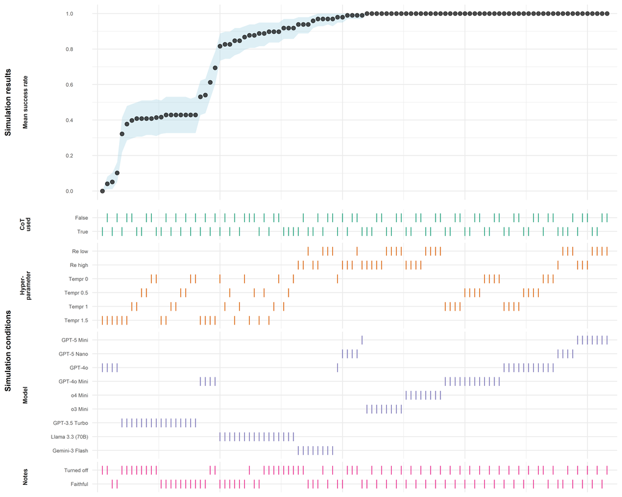

```r
data_prepared_success <- data_plot |>
  # Preprocess
  dplyr::select(
    `Model`,
    `Hyper-<br> parameter`,
    `CoT<br> used`,
    `Notes`,
    mean_success,
    boot_success_rate_lower,
    boot_success_rate_upper
  ) |>
  # Summarize
  group_by(Model, `Hyper-<br> parameter`, `CoT<br> used`, Notes) |>
  summarise(
    success_rate = mean(mean_success, na.rm = TRUE),
    boot_success_lower = mean(boot_success_rate_lower, na.rm = TRUE),
    boot_success_upper = mean(boot_success_rate_upper, na.rm = TRUE),
    .groups = "drop"
  )

# Minimum and maximum data points
min_config_success <- min(data_prepared_success$success_rate, na.rm = TRUE)
max_config_success <- max(data_prepared_success$success_rate, na.rm = TRUE)

# Inference: Overlap of confidence intervals (With safety na.rm = TRUE)
lower_bound_max_success <- max(data_prepared_success$boot_success_lower, na.rm = TRUE)
upper_bound_min_success <- min(data_prepared_success$boot_success_upper, na.rm = TRUE)
cis_all_overlap_success <- lower_bound_max_success <= upper_bound_min_success

# Plotting
success_spec_plot <- data_prepared_success |>
  arrange(success_rate) |>
  mutate(rank = row_number()) |>
  # Plot call
  specification_curve_plot_with_shading(
    outcome = success_rate,
    outcome_name = "Mean success rate",
    interval_lower = "boot_success_lower",
    interval_upper = "boot_success_upper",
    rank_by = rank,
    mutate_plots = \(top, bottom, df) {
      list(top + coord_cartesian(ylim = c(0, 1)))
    }
  )

success_spec_plot
```

```r
ggsave(
  filename = "output/plots/success_spec_plot.png",
  plot = success_spec_plot,
  width = PLOT_WIDTH,
  height = PLOT_HEIGHT,
  dpi = PLOT_DPI
)
```

The estimated operational success rate of the configurations ranged from 0% to 100%, with confidence intervals that do not universally overlap.

# Exploratory

## Data transformation and calculation

```r
# Create summary
review_data_summary_expl <- review_data_calculated |>
  group_by(across(all_of(CONFIG_COL))) |>
  summarise(
    # Exploratory: SDs of quality metrics
    across(all_of(SCORE_COL), ~ sd(.x, na.rm = TRUE), .names = "sd_{.col}"),
    .groups = "drop"
  )
```

## Bootstrap

```r
# Set alpha level
global_alpha <- (1 - CONFIDENCE_LVL) / 2

# Define bootstrap function
#' Bootstrap Confidence Interval Generation
#'
#' Performs non-parametric bootstrapping to estimate uncertainty for given metrics
#'
#' @param df A data frame containing the review-level data.
#' @param group_col A character string specifying the column to group by
#' @param iterations Integer. The number of bootstrap resamples to perform.
#'   Defaults to the global \code{NUM_ITERATIONS}.
#'
#' @return A data frame containing the lower and upper confidence bounds.
#'   Columns are named using the pattern:
#'   \code{boot_[original_metric]_[lower/upper]}
bootstrap_sd <- function(df, group_col, iterations = NUM_ITERATIONS) {
  set.seed(42)

  # Generate the distribution
  boot_distribution <- map_df(1:iterations, function(i) {
    df |>
      # Group by configuration
      group_by(.data[[group_col]]) |>
      # Sample with replacement
      slice_sample(prop = 1, replace = TRUE) |>
      summarise(
        # Exploratory: SDs of quality metrics
        across(all_of(SCORE_COL),
          ~ sd(.x, na.rm = TRUE),
          .names = "boot_{.col}"
        ),
        .groups = "drop"
      )
  })

  # Calculate CIs
  ci_results <- boot_distribution |>
    # Group by configuration
    group_by(.data[[group_col]]) |>
    summarise(
      across(starts_with("boot_"),
        list(
          lower = ~ quantile(.x, global_alpha, na.rm = TRUE),
          upper = ~ quantile(.x, 1 - global_alpha, na.rm = TRUE)
        ),
        .names = "{.col}_{.fn}"
      ),
      .groups = "drop"
    )

  return(ci_results)
}
```

```r
boot_results_expl <- bootstrap_sd(review_data_calculated, "config_group")
```

```r
review_data_bootstraped_expl <- review_data_summary_expl |>
  left_join(boot_results_expl, "config_group")
```

## Data preparation

```r
data_plot_expl <- review_data_bootstraped_expl |>
  mutate(
    model = fct_relevel(
      as.factor(model),
      "Gemini-3 Flash", "Llama 3.3 (70B)", "GPT-3.5 Turbo", "o3 Mini",
      "o4 Mini", "GPT-4o Mini", "GPT-4o", "GPT-5 Nano", "GPT-5 Mini"
    ),
    hyperparameter = fct_relevel(
      as.factor(hyperparameter),
      "Tempr 1.5", "Tempr 1", "Tempr 0.5", "Tempr 0", "Re high", "Re low"
    ),
    chain_of_thought = fct_relevel(
      as.factor(chain_of_thought),
      "True", "False"
    ),
    note_taking = fct_relevel(
      as.factor(note_taking),
      "Faithful", "Turned off"
    )
  ) |>
  rename(
    `Model` = model,
    `Hyper-<br> parameter` = hyperparameter,
    `CoT<br> used` = chain_of_thought,
    `Notes` = note_taking
  )
```

## Specification curve: Helpfulness

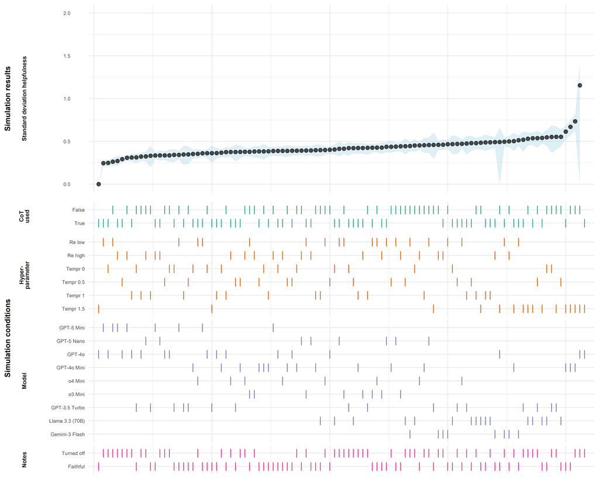

```r
data_prepared_helpfulness_expl <- data_plot_expl |>
  # Preprocess
  dplyr::select(
    `Model`,
    `Hyper-<br> parameter`,
    `CoT<br> used`,
    `Notes`,
    sd_helpfulness_label,
    boot_helpfulness_label_lower,
    boot_helpfulness_label_upper
  ) |>
  # Summarize
  group_by(Model, `Hyper-<br> parameter`, `CoT<br> used`, Notes) |>
  summarise(
    helpfulness_sd = mean(sd_helpfulness_label, na.rm = TRUE),
    boot_helpfulness_lower = mean(boot_helpfulness_label_lower, na.rm = TRUE),
    boot_helpfulness_upper = mean(boot_helpfulness_label_upper, na.rm = TRUE),
    .groups = "drop"
  )

# Minimum and maximum data points
min_config_sd_helpfulness <- min(data_prepared_helpfulness_expl$helpfulness_sd, na.rm = TRUE)
max_config_sd_helpfulness <- max(data_prepared_helpfulness_expl$helpfulness_sd, na.rm = TRUE)

# Inference: Overlap of confidence intervals
lower_bound_max_helpfulness_expl <- max(data_prepared_helpfulness_expl$boot_helpfulness_lower, na.rm = TRUE)
upper_bound_min_helpfulness_expl <- min(data_prepared_helpfulness_expl$boot_helpfulness_upper, na.rm = TRUE)
cis_all_overlap_helpfulness_expl <- lower_bound_max_helpfulness_expl <= upper_bound_min_helpfulness_expl

# Plotting
helpfulness_spec_plot_expl <- data_prepared_helpfulness_expl |>
  arrange(helpfulness_sd) |>
  mutate(rank = row_number()) |>
  # Plot call
  specification_curve_plot_with_shading(
    outcome = helpfulness_sd,
    outcome_name = "Standard deviation helpfulness",
    interval_lower = "boot_helpfulness_lower",
    interval_upper = "boot_helpfulness_upper",
    rank_by = rank,
    mutate_plots = \(top, bottom, df) {
      list(top + coord_cartesian(ylim = c(0, 2)))
    }
  )

helpfulness_spec_plot_expl
```

```r
ggsave(
  filename = "output/plots/helpfulness_spec_plot_expl.png",
  plot = helpfulness_spec_plot_expl,
  width = PLOT_WIDTH,
  height = PLOT_HEIGHT,
  dpi = PLOT_DPI
)
```

The estimated between-paper standard deviation of the helpfulness metric ranged from 0 to 1.15, with confidence intervals that do not universally overlap.

# References

Cummins, J. (2026). The threat of analytic flexibility in using large language models to simulate human data. *Advances in Methods and Practices in Psychological Science*, *9*(3), Article 25152459261461505. https://doi.org/10.1177/25152459261461505